# # Introduction to Statistical Learning - Chapter 6

## Question 1

1. We expect the model found by best subset method to have the smallest training RSS, because best subset method looks at all the models with $k$ predictors and chooses the one with the smallest error.
2. We don’t know; we probably expect the model from best subset to have the smallest test RSS, but it is not guaranteed.
3. i, ii are true; rest are false.

## Question 2

1. iii is true.
2. Again iii is true.
3. ii is true.

## Question 3

1. When s=0, all coefficients will be 0 except the intercept. As s gets larger, the coefficients become less constrained; hence the problem becomes more least-squares like. So, training RSS will steadily decrease.  
   b.Test RSS will decrease first, but it will eventually start increasing (I think this also depends on the problem; for some problems the least-squares solution might be the best.).
2. Variance will increase (model becomes more flexible.).
3. Bias will decrease.
4. Irreducible error does not change.

## Question 4

This question is same with the previous one, only the question is phrased in terms of $\lambda$ rather than s. So the answers are just the opposites of what we said for Question 3.

## Question 5

Let us assume that $x_{11} = x_{12} = a$, $x_{21} = x_{22} = -a$, and $y1 = y$, $y2 = -y$. Then the optimization problem solved by ridge regression is $\text{E}_R = (y - (\beta_1 a + \beta_2 a))^2 + (-y - (-\beta_1 a - \beta_2 a))^2 + \lambda (\beta_1^2 + \beta_2^2) \\ = 2(y - (\beta_1 a + \beta_2 a))^2 + \lambda (\beta_1^2 + \beta_2^2)$  
Set the derivatives with respect to coefficients to zero to find the optimum values.  
$\frac{\partial}{\partial \beta_1} = -4(y - \beta_1 a - \beta_2 a)a + 2 \lambda \beta_1 \\ -4ay + 4a^2 \beta_1 + 4a^2 \beta_2 + 2 \lambda \beta_1 = 0 \\ (4a^2 + 2 \lambda) \beta_1 + (4a^2) \beta_2 = 4ay$ The derivation for $\beta_2$ is exactly symmetric, so $(4a^2) \beta_1 + (4a^2 + 2 \lambda) \beta_2 = 4ay$ Note that as long as $\lambda$ is not zero, these two equations are independent (different), meaning that we get unique solutions. These solutions are $\beta_1 = \beta_2 = \frac{2ay}{4a^2 + \lambda}$

Now let us look at lasso. We write down the optimization problem. $E_L = (y - (\beta_1 a + \beta_2 a))^2 + (-y - (-\beta_1 a - \beta_2 a))^2 + \lambda (|\beta_1| + |\beta_2|) \\ = 2(y - (\beta_1 a + \beta_2 a))^2 + \lambda (|\beta_1| + |\beta_2|)$ Let us assume that $\beta_1>0$ and $\beta_2>0$. Set the derivative with respect to $\beta_1$ to zero. $\frac{\partial}{\partial \beta_1} = -4(y - \beta_1 a - \beta_2 a)a + \lambda \\ -4ay + 4a^2 \beta_1 + 4a^2 \beta_2 + \lambda = 0 \\ (4a^2) \beta_1 + (4a^2) \beta_2 = 4ay - \lambda$ The derivative with respect to $\beta_2$ is exactly the same with the derivative with respect to $\beta_1$, so we get the same equation. $(4a^2) \beta_1 + (4a^2) \beta_2 = 4ay - \lambda$ Now we do not have two independent equations, but a single one. So only thing we can say about the coefficients is that their sum is given as follows. $\beta_1 + \beta_2 = \frac{4ay - \lambda}{4a^2}$ So any pair of values giving the above sum will be an optimum value, in other words, optimum value is not a single point, but a line.

Another way to think about this is as follows. Let us look at the optimization problems for both of the problems. Assume that for the optimum solution the first term in the following problems vanish, only the second term matters. If first terms vanish, $\beta_1 + \beta_2 = \frac{y}{a}$, meaning that the sum of the coefficients is fixed. Now the difference between ridge and lasso comes down to this: for a pair of numbers with a known sum, what is the minimum value of the second term. For ridge, the minimum of $\lambda (\beta_1^2 + \beta_2^2)$ is achieved when $\beta_1=\beta_2$. For lasso, the minimum of $\lambda (|\beta_1| + |\beta_2|)$ can be achieved with any pair of numbers that sum to the given number. $E_R = 2(y - (\beta_1 a + \beta_2 a))^2 + \lambda (\beta_1^2 + \beta_2^2) \\ E_L = 2(y - (\beta_1 a + \beta_2 a))^2 + \lambda (|\beta_1| + |\beta_2|) \\$

## Question 8

Generate data

```r
set.seed(1)
x = rnorm(100)
err = rnorm(100)
y = 0.2 + 0.3*x + 0.4*x^2 + 0.5*x^3 + err
df =cbind(as.data.frame(poly(x, degree = 10, raw=T)), y)
head(df)
```

```
##         1       2         3        4          5         6          7
## 1 -0.6265 0.39244 -0.245848 0.154013 -0.0964818 6.044e-02 -3.786e-02
## 2  0.1836 0.03372  0.006193 0.001137  0.0002089 3.836e-05  7.044e-06
## 3 -0.8356 0.69828 -0.583499 0.487588 -0.4074427 3.405e-01 -2.845e-01
## 4  1.5953 2.54492  4.059863 6.476622 10.3320309 1.648e+01  2.629e+01
## 5  0.3295 0.10858  0.035776 0.011789  0.0038844 1.280e-03  4.218e-04
## 6 -0.8205 0.67317 -0.552313 0.453156 -0.3717999 3.051e-01 -2.503e-01
##           8          9        10       y
## 1 2.372e-02 -1.486e-02 9.309e-03 -0.5742
## 2 1.294e-06  2.376e-07 4.363e-08  0.3138
## 3 2.377e-01 -1.987e-01 1.660e-01 -0.9740
## 4 4.195e+01  6.692e+01 1.068e+02  3.8845
## 5 1.390e-04  4.579e-05 1.509e-05 -0.2944
## 6 2.054e-01 -1.685e-01 1.382e-01  1.7143
```

Run best subset selection.

```r
library(leaps)
reg.full = regsubsets(y~., df, nvmax=10)
reg.summary = summary(reg.full)
reg.summary
```

```
## Subset selection object
## Call: regsubsets.formula(y ~ ., df, nvmax = 10)
## 10 Variables  (and intercept)
##      Forced in Forced out
## `1`      FALSE      FALSE
## `2`      FALSE      FALSE
## `3`      FALSE      FALSE
## `4`      FALSE      FALSE
## `5`      FALSE      FALSE
## `6`      FALSE      FALSE
## `7`      FALSE      FALSE
## `8`      FALSE      FALSE
## `9`      FALSE      FALSE
## `10`     FALSE      FALSE
## 1 subsets of each size up to 10
## Selection Algorithm: exhaustive
##           `1` `2` `3` `4` `5` `6` `7` `8` `9` `10`
## 1  ( 1 )  " " " " "*" " " " " " " " " " " " " " "
## 2  ( 1 )  " " " " "*" "*" " " " " " " " " " " " "
## 3  ( 1 )  "*" " " " " "*" "*" " " " " " " " " " "
## 4  ( 1 )  "*" " " " " "*" "*" " " " " " " "*" " "
## 5  ( 1 )  "*" "*" " " " " "*" " " " " "*" "*" " "
## 6  ( 1 )  "*" " " " " "*" "*" "*" " " "*" " " "*"
## 7  ( 1 )  "*" "*" " " "*" "*" "*" " " "*" " " "*"
## 8  ( 1 )  "*" "*" "*" "*" " " "*" " " "*" "*" "*"
## 9  ( 1 )  "*" "*" " " "*" "*" "*" "*" "*" "*" "*"
## 10  ( 1 ) "*" "*" "*" "*" "*" "*" "*" "*" "*" "*"
```

Note that these results do not look good at all. The best 3 variable model contains $X^4$ and $X^5$!

Plot $C_p$, BIC, and adjusted $R^2$.

[figure not shown]

```r
plot(reg.summary$cp, type='l')
```

```r
which.min(reg.summary$cp)
```

```
## [1] 3
```

[figure not shown]

```r
plot(reg.summary$bic, type='l')
```

```r
which.min(reg.summary$bic)
```

```
## [1] 3
```

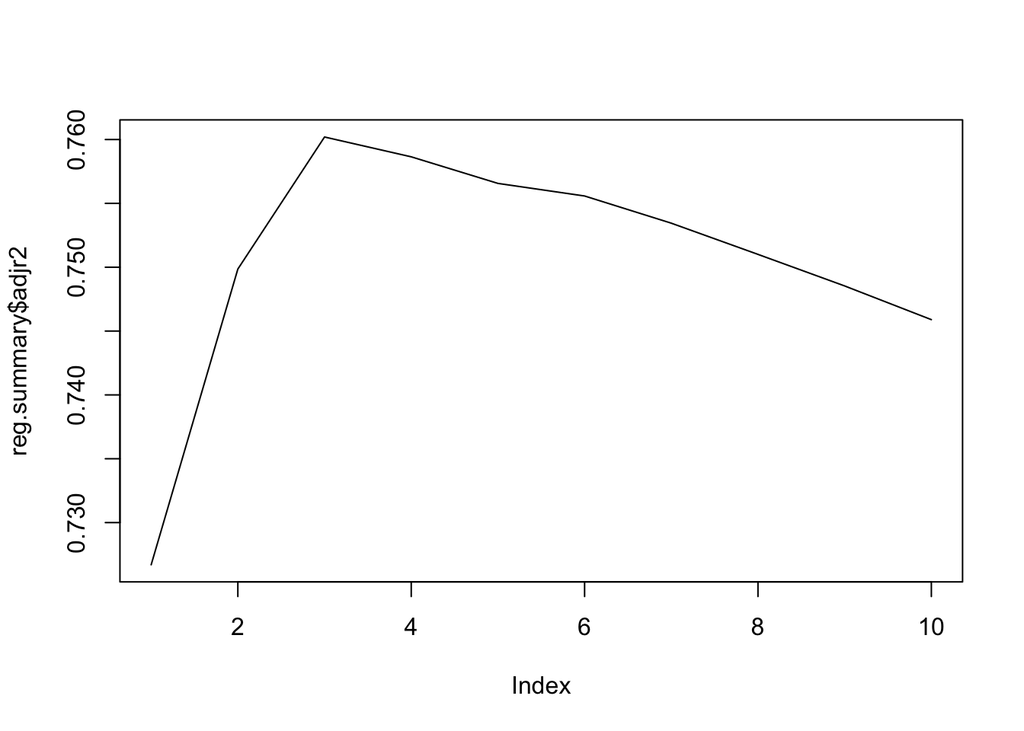

```r
plot(reg.summary$adjr2, type='l')
```

```r
which.max(reg.summary$adjr2)
```

```
## [1] 3
```

All of the measures tell us that the model with 3 predictors is the best. Let us look at the coefficients for that model.

```r
coef(reg.full, id=3)
```

```
## (Intercept)         `1`         `4`         `5`
##     0.35966     0.77584     0.05619     0.08608
```

Let us do the same thing using forward selection.

```r
reg.fwd = regsubsets(y~., df, nvmax=10, method = 'forward')
reg.fwd_summary = summary(reg.fwd)
reg.fwd_summary
```

```
## Subset selection object
## Call: regsubsets.formula(y ~ ., df, nvmax = 10, method = "forward")
## 10 Variables  (and intercept)
##      Forced in Forced out
## `1`      FALSE      FALSE
## `2`      FALSE      FALSE
## `3`      FALSE      FALSE
## `4`      FALSE      FALSE
## `5`      FALSE      FALSE
## `6`      FALSE      FALSE
## `7`      FALSE      FALSE
## `8`      FALSE      FALSE
## `9`      FALSE      FALSE
## `10`     FALSE      FALSE
## 1 subsets of each size up to 10
## Selection Algorithm: forward
##           `1` `2` `3` `4` `5` `6` `7` `8` `9` `10`
## 1  ( 1 )  " " " " "*" " " " " " " " " " " " " " "
## 2  ( 1 )  " " " " "*" "*" " " " " " " " " " " " "
## 3  ( 1 )  "*" " " "*" "*" " " " " " " " " " " " "
## 4  ( 1 )  "*" " " "*" "*" "*" " " " " " " " " " "
## 5  ( 1 )  "*" "*" "*" "*" "*" " " " " " " " " " "
## 6  ( 1 )  "*" "*" "*" "*" "*" " " " " " " "*" " "
## 7  ( 1 )  "*" "*" "*" "*" "*" "*" " " " " "*" " "
## 8  ( 1 )  "*" "*" "*" "*" "*" "*" "*" " " "*" " "
## 9  ( 1 )  "*" "*" "*" "*" "*" "*" "*" "*" "*" " "
## 10  ( 1 ) "*" "*" "*" "*" "*" "*" "*" "*" "*" "*"
```

Plot $C_p$, BIC, and adjusted $R^2$.

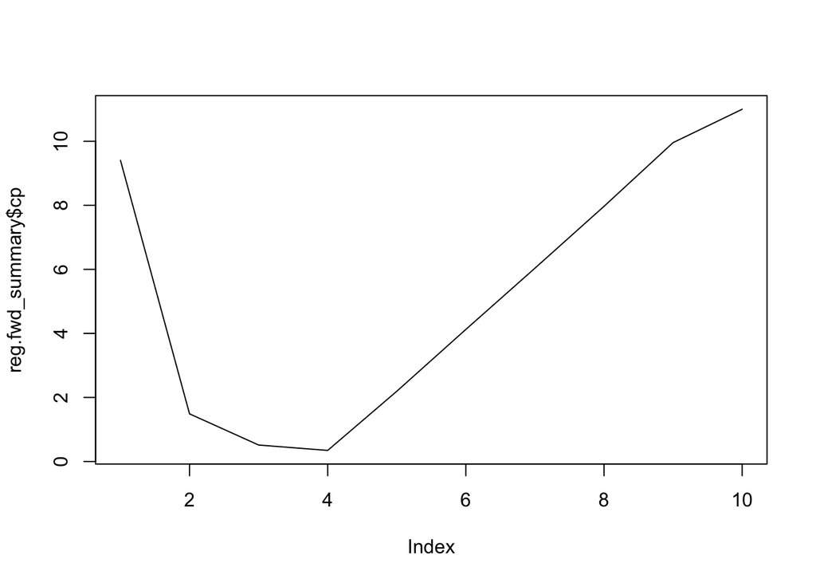

```r
plot(reg.fwd_summary$cp, type='l')
```

```r
which.min(reg.fwd_summary$cp)
```

```
## [1] 4
```

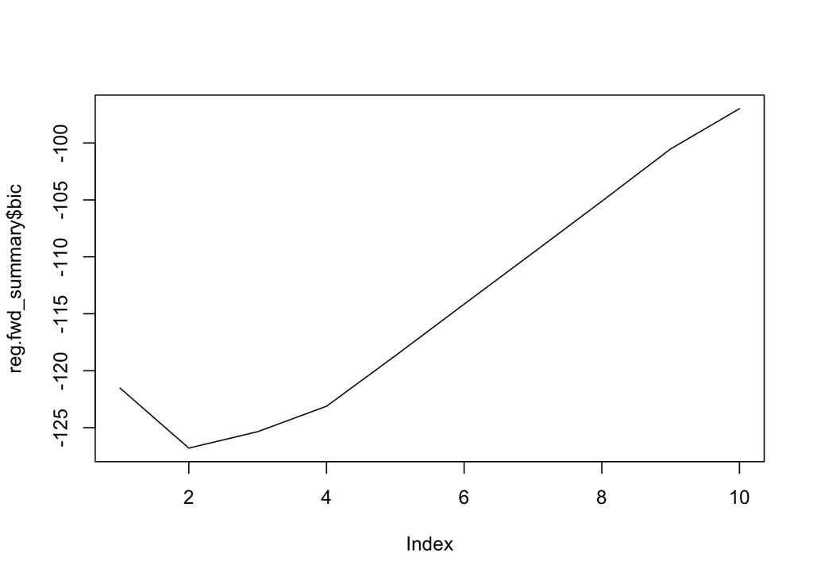

```r
plot(reg.fwd_summary$bic, type='l')
```

```r
which.min(reg.fwd_summary$bic)
```

```
## [1] 2
```

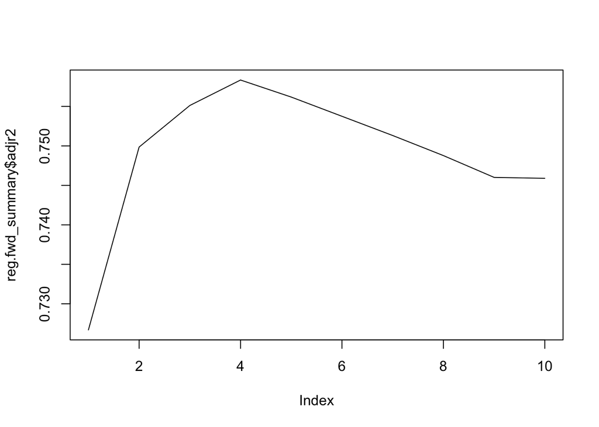

```r
plot(reg.fwd_summary$adjr2, type='l')
```

```r
which.max(reg.fwd_summary$adjr2)
```

```
## [1] 4
```

Now these measures tell us different things!

Let us do the backward selection.

```r
reg.bwd = regsubsets(y~., df, nvmax=10, method = 'backward')
reg.bwd_summary = summary(reg.bwd)
reg.bwd_summary
```

```
## Subset selection object
## Call: regsubsets.formula(y ~ ., df, nvmax = 10, method = "backward")
## 10 Variables  (and intercept)
##      Forced in Forced out
## `1`      FALSE      FALSE
## `2`      FALSE      FALSE
## `3`      FALSE      FALSE
## `4`      FALSE      FALSE
## `5`      FALSE      FALSE
## `6`      FALSE      FALSE
## `7`      FALSE      FALSE
## `8`      FALSE      FALSE
## `9`      FALSE      FALSE
## `10`     FALSE      FALSE
## 1 subsets of each size up to 10
## Selection Algorithm: backward
##           `1` `2` `3` `4` `5` `6` `7` `8` `9` `10`
## 1  ( 1 )  " " " " " " " " "*" " " " " " " " " " "
## 2  ( 1 )  "*" " " " " " " "*" " " " " " " " " " "
## 3  ( 1 )  "*" " " " " "*" "*" " " " " " " " " " "
## 4  ( 1 )  "*" "*" " " "*" "*" " " " " " " " " " "
## 5  ( 1 )  "*" "*" "*" "*" "*" " " " " " " " " " "
## 6  ( 1 )  "*" " " " " "*" "*" "*" " " "*" " " "*"
## 7  ( 1 )  "*" "*" " " "*" "*" "*" " " "*" " " "*"
## 8  ( 1 )  "*" "*" " " "*" "*" "*" " " "*" "*" "*"
## 9  ( 1 )  "*" "*" " " "*" "*" "*" "*" "*" "*" "*"
## 10  ( 1 ) "*" "*" "*" "*" "*" "*" "*" "*" "*" "*"
```

Plot $C_p$, BIC, and adjusted $R^2$.

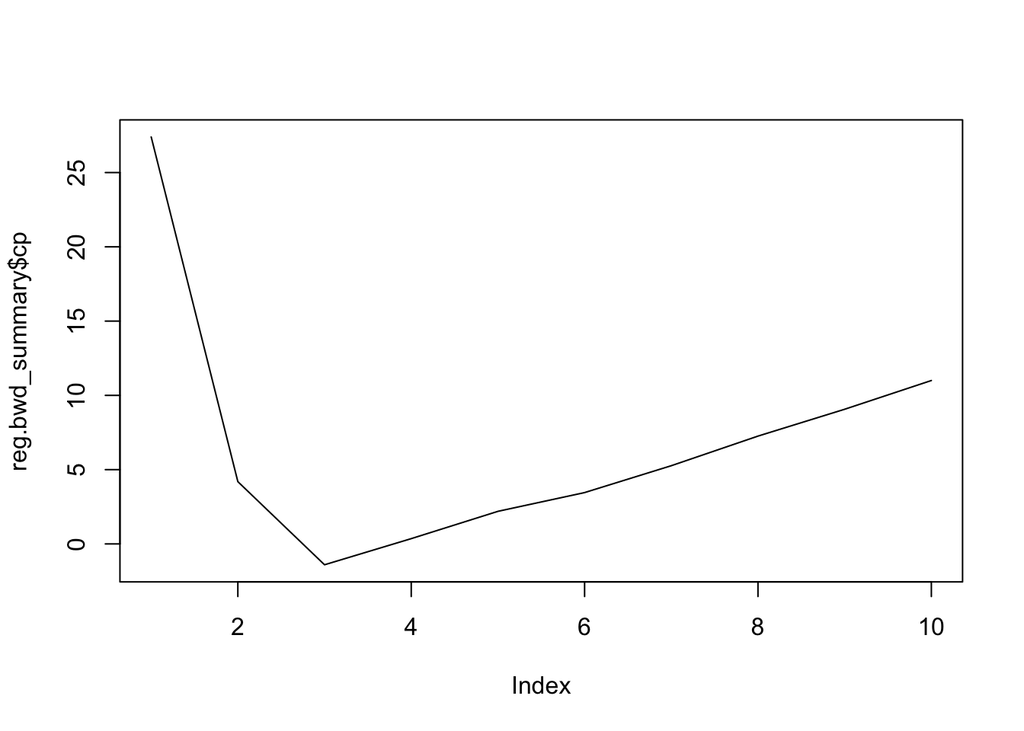

```r
plot(reg.bwd_summary$cp, type='l')
```

```r
which.min(reg.bwd_summary$cp)
```

```
## [1] 3
```

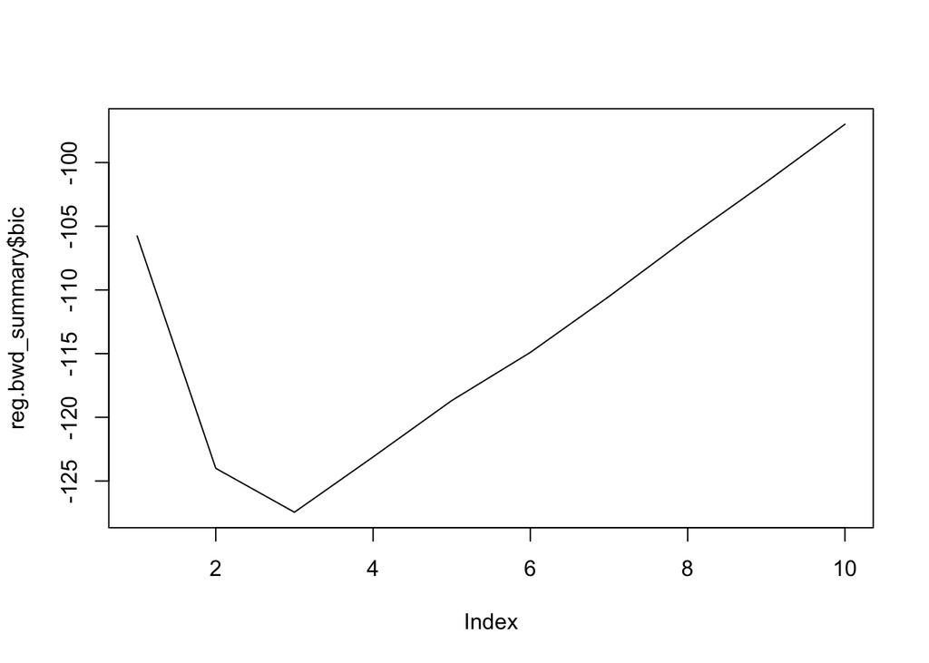

```r
plot(reg.bwd_summary$bic, type='l')
```

```r
which.min(reg.bwd_summary$bic)
```

```
## [1] 3
```

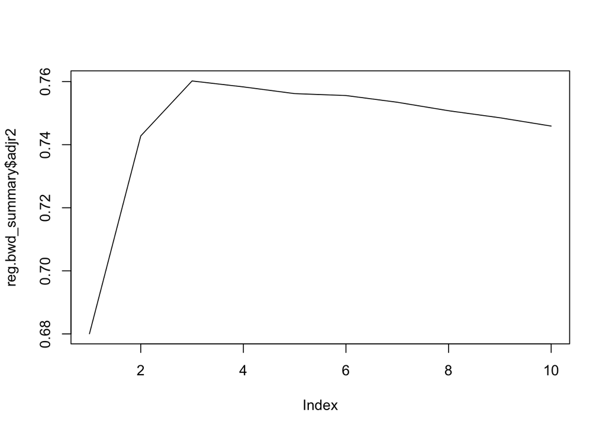

```r
plot(reg.bwd_summary$adjr2, type='l')
```

```r
which.max(reg.bwd_summary$adjr2)
```

```
## [1] 3
```

At least now all the measures agree!

Let us fit lasso and look at the crossvalidation error.

```r
library(glmnet)
```

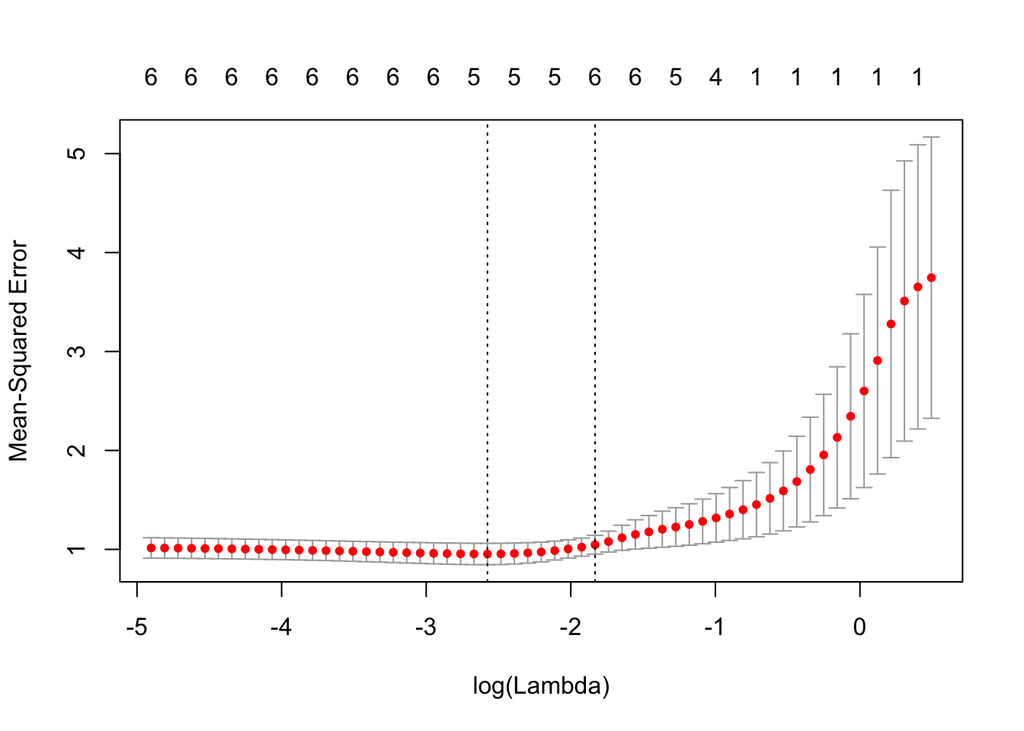

```r
mx = model.matrix(y~., df)[,-1]
fit.lasso = cv.glmnet(x = mx, y = y, alpha=1)
plot(fit.lasso)
```

The best cv error is reached at lambda

```r
fit.lasso$lambda.min
```

```
## [1] 0.07605
```

The coefficients are

```r
coef(fit.lasso, s='lambda.min')
```

```
## 11 x 1 sparse Matrix of class "dgCMatrix"
##                   1
## (Intercept) 0.37911
## `1`         0.51354
## `2`         0.03043
## `3`         0.19829
## `4`         0.04106
## `5`         0.05218
## `6`         .
## `7`         .
## `8`         .
## `9`         .
## `10`        .
```

Now generate data according to the second model.

```r
y = 0.2 + 0.3*x^7 + err
df$y = y
```

Run best subset selection.

```r
reg.full = regsubsets(y~., df, nvmax=10)
reg.summary = summary(reg.full)
reg.summary
```

```
## Subset selection object
## Call: regsubsets.formula(y ~ ., df, nvmax = 10)
## 10 Variables  (and intercept)
##      Forced in Forced out
## `1`      FALSE      FALSE
## `2`      FALSE      FALSE
## `3`      FALSE      FALSE
## `4`      FALSE      FALSE
## `5`      FALSE      FALSE
## `6`      FALSE      FALSE
## `7`      FALSE      FALSE
## `8`      FALSE      FALSE
## `9`      FALSE      FALSE
## `10`     FALSE      FALSE
## 1 subsets of each size up to 10
## Selection Algorithm: exhaustive
##           `1` `2` `3` `4` `5` `6` `7` `8` `9` `10`
## 1  ( 1 )  " " " " " " " " " " " " "*" " " " " " "
## 2  ( 1 )  " " "*" " " " " " " " " "*" " " " " " "
## 3  ( 1 )  " " "*" " " " " "*" " " "*" " " " " " "
## 4  ( 1 )  "*" "*" "*" " " " " " " "*" " " " " " "
## 5  ( 1 )  "*" "*" "*" "*" " " " " "*" " " " " " "
## 6  ( 1 )  "*" " " "*" " " " " "*" "*" "*" " " "*"
## 7  ( 1 )  "*" " " "*" " " "*" "*" "*" "*" " " "*"
## 8  ( 1 )  "*" "*" "*" "*" " " "*" "*" "*" " " "*"
## 9  ( 1 )  "*" "*" "*" "*" "*" "*" " " "*" "*" "*"
## 10  ( 1 ) "*" "*" "*" "*" "*" "*" "*" "*" "*" "*"
```

It seems to have worked better; one variable model contains $X_7$.

Plot $C_p$, BIC, and adjusted $R^2$.

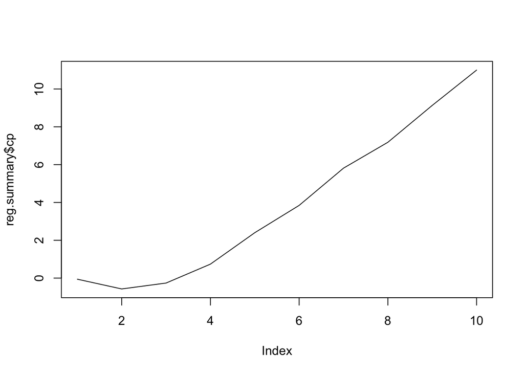

```r
plot(reg.summary$cp, type='l')
```

```r
which.min(reg.summary$cp)
```

```
## [1] 2
```

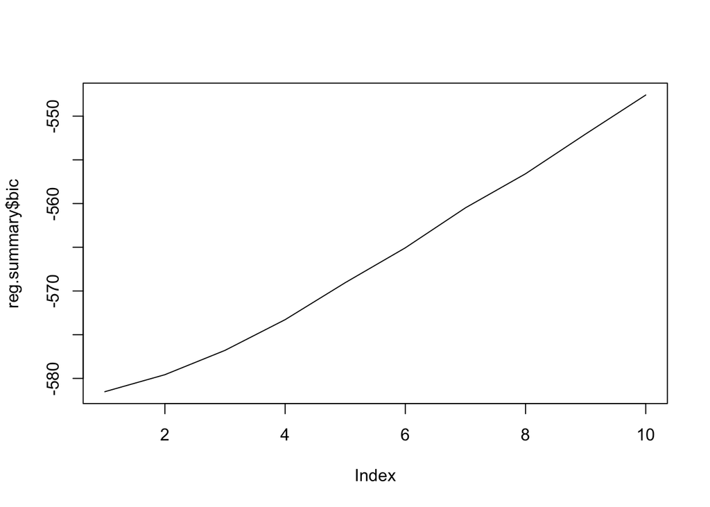

```r
plot(reg.summary$bic, type='l')
```

```r
which.min(reg.summary$bic)
```

```
## [1] 1
```

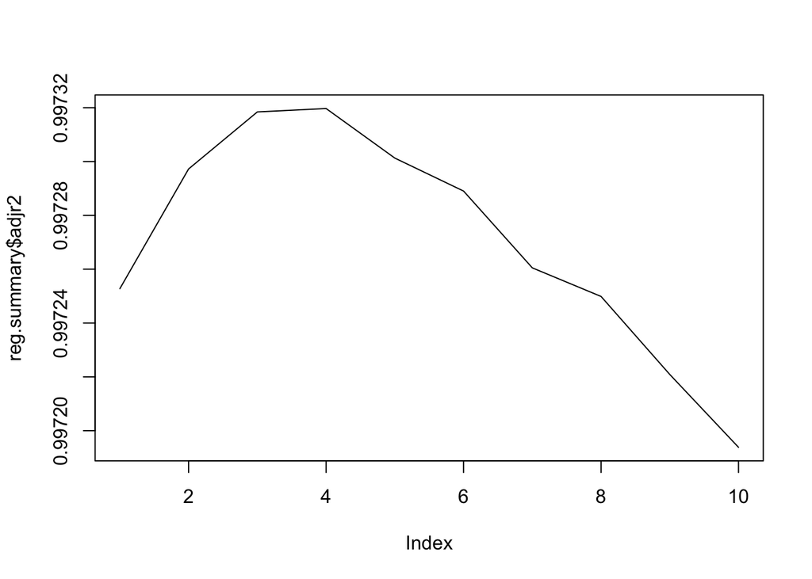

```r
plot(reg.summary$adjr2, type='l')
```

```r
which.max(reg.summary$adjr2)
```

```
## [1] 4
```

Let us see what lasso does.

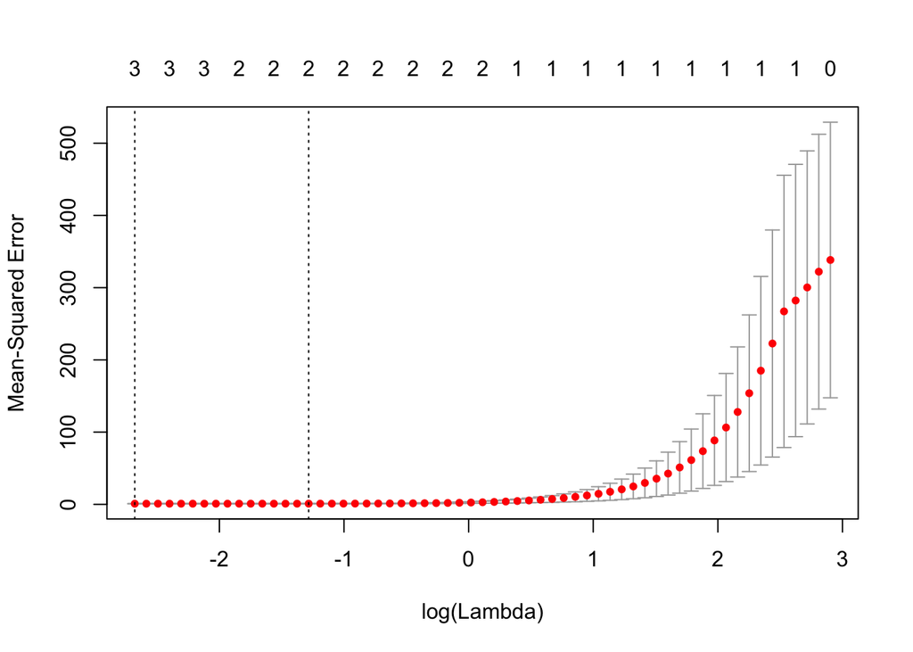

```r
mx = model.matrix(y~., df)[,-1]
fit.lasso = cv.glmnet(x = mx, y = y, alpha=1)
plot(fit.lasso)
```

The best cv error is reached at lambda

```r
fit.lasso$lambda.min
```

```
## [1] 0.06863
```

The coefficients are

```r
coef(fit.lasso, s='lambda.min')
```

```
## 11 x 1 sparse Matrix of class "dgCMatrix"
##                     1
## (Intercept)  0.215495
## `1`          .
## `2`         -0.068587
## `3`          .
## `4`          .
## `5`          .
## `6`          .
## `7`          0.293825
## `8`          .
## `9`          0.001193
## `10`         .
```

Not bad. The coefficient for $X^7$ is pretty close to its actual value. I guess the take home message 1 is do not use BIC etc., just do cross-validation!

## Question 9

```r
library(ISLR)
set.seed(1)
train = sample(c(T,F), size = nrow(College), replace = T)
test = !train
```

Fit a linear model.

```r
lm.fit = lm(Apps~., data = College, subset = train)
summary(lm.fit)
```

```
##
## Call:
## lm(formula = Apps ~ ., data = College, subset = train)
##
## Residuals:
##    Min     1Q Median     3Q    Max
##  -2485   -392    -58    262   6637
##
## Coefficients:
##              Estimate Std. Error t value Pr(>|t|)
## (Intercept) -756.8873   535.4422   -1.41  0.15830
## PrivateYes  -515.3646   190.4420   -2.71  0.00711 **
## Accept         1.2092     0.0705   17.16  < 2e-16 ***
## Enroll        -0.2903     0.2338   -1.24  0.21519
## Top10perc     52.5377     7.6936    6.83  3.4e-11 ***
## Top25perc    -16.3897     6.0971   -2.69  0.00750 **
## F.Undergrad    0.0962     0.0410    2.35  0.01949 *
## P.Undergrad    0.0283     0.0542    0.52  0.60154
## Outstate      -0.0216     0.0260   -0.83  0.40626
## Room.Board     0.1320     0.0697    1.89  0.05885 .
## Books          0.1664     0.3409    0.49  0.62573
## Personal       0.1641     0.0927    1.77  0.07752 .
## PhD           -8.5181     6.7392   -1.26  0.20701
## Terminal      -0.3538     7.4306   -0.05  0.96205
## S.F.Ratio      3.7944    16.2078    0.23  0.81503
## perc.alumni   -2.8629     5.5667   -0.51  0.60735
## Expend         0.0586     0.0153    3.83  0.00015 ***
## Grad.Rate      7.1493     3.9109    1.83  0.06832 .
## ---
## Signif. codes:  0 '***' 0.001 '**' 0.01 '*' 0.05 '.' 0.1 ' ' 1
##
## Residual standard error: 1000 on 382 degrees of freedom
## Multiple R-squared:  0.931,  Adjusted R-squared:  0.928
## F-statistic:  305 on 17 and 382 DF,  p-value: <2e-16
```

```r
cor(College$Accept, College$Enroll)
```

```
## [1] 0.9116
```

Calculate MSE.

```r
lm.pred = predict(object = lm.fit, newdata = College[test,])
lm.err = mean((lm.pred - College[test, 'Apps'])^2) / nrow(College[test,])
lm.err
```

```
## [1] 4033
```

Fit a ridge regression model.

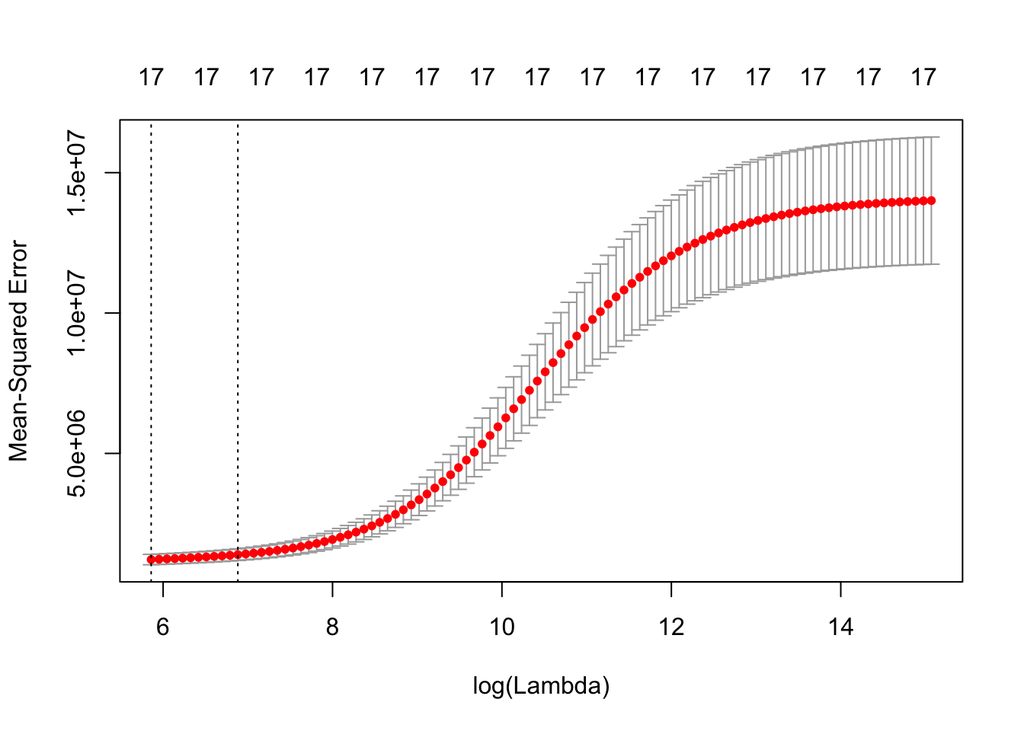

```r
library(glmnet)
set.seed(1)
mx = model.matrix(Apps~., College)[,-1]
trainy = College[train, 'Apps']
trainx = mx[train,]
testx = mx[test,]
ridge.fit = cv.glmnet(x = trainx, y = trainy, alpha = 0)
plot(ridge.fit)
```

```r
ridge.pred = predict(object = ridge.fit, newx = testx, s = 'lambda.min')
ridge.err = mean((ridge.pred - College[test, 'Apps'])^2) / nrow(College[test,])
ridge.err
```

```
## [1] 6722
```

Fit a lasso regression model.

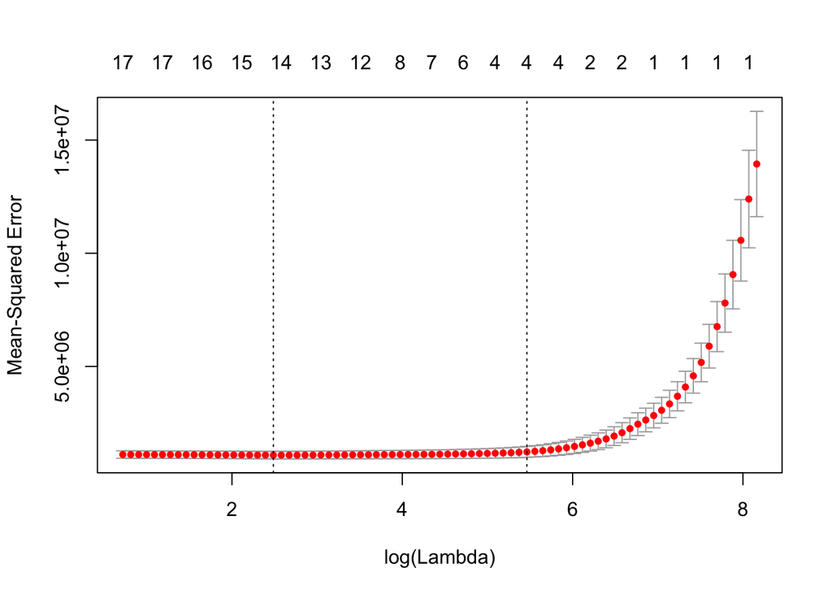

```r
set.seed(1)
lasso.fit = cv.glmnet(x = trainx, y = trainy, alpha = 1)
plot(lasso.fit)
```

```r
lasso.pred = predict(object = lasso.fit, newx = testx, s = 'lambda.min')
lasso.err = mean((lasso.pred - College[test, 'Apps'])^2) / nrow(College[test,])
lasso.err
```

```
## [1] 4268
```

```r
coef(lasso.fit, s = 'lambda.min')
```

```
## 18 x 1 sparse Matrix of class "dgCMatrix"
##                      1
## (Intercept) -8.551e+02
## PrivateYes  -4.957e+02
## Accept       1.150e+00
## Enroll       .
## Top10perc    4.401e+01
## Top25perc   -9.741e+00
## F.Undergrad  6.909e-02
## P.Undergrad  2.258e-02
## Outstate    -4.479e-03
## Room.Board   1.075e-01
## Books        1.185e-01
## Personal     1.450e-01
## PhD         -7.193e+00
## Terminal     .
## S.F.Ratio    .
## perc.alumni -3.547e+00
## Expend       5.599e-02
## Grad.Rate    5.503e+00
```

Fit PCR.

```r
set.seed(1)
library(pls)
```

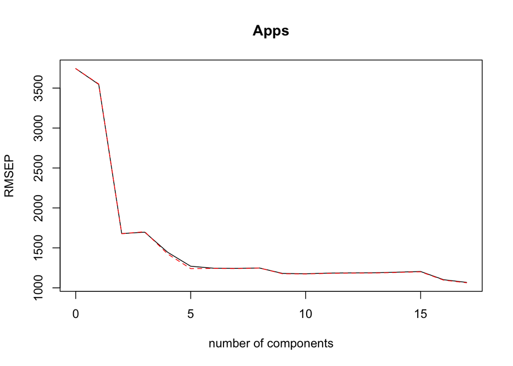

```r
pcr.fit = pcr(Apps~., data = College, subset=train, scale=T, validation='CV')
validationplot(pcr.fit)
```

```r
summary(pcr.fit)
```

```
## Data:    X dimension: 400 17
##  Y dimension: 400 1
## Fit method: svdpc
## Number of components considered: 17
##
## VALIDATION: RMSEP
## Cross-validated using 10 random segments.
##        (Intercept)  1 comps  2 comps  3 comps  4 comps  5 comps  6 comps
## CV            3744     3546     1679     1697     1445     1270     1245
## adjCV         3744     3551     1677     1703     1424     1241     1243
##        7 comps  8 comps  9 comps  10 comps  11 comps  12 comps  13 comps
## CV        1244     1248     1180      1176      1184      1187      1189
## adjCV     1241     1248     1176      1173      1182      1184      1186
##        14 comps  15 comps  16 comps  17 comps
## CV         1196      1205      1102      1068
## adjCV      1193      1201      1097      1064
##
## TRAINING: % variance explained
##       1 comps  2 comps  3 comps  4 comps  5 comps  6 comps  7 comps
## X       32.07    58.34    64.91    70.53    75.95    81.04    84.82
## Apps    11.14    80.28    80.29    86.40    89.31    89.41    89.47
##       8 comps  9 comps  10 comps  11 comps  12 comps  13 comps  14 comps
## X       88.19    91.14     93.51     95.61     97.27     98.31     99.01
## Apps    89.57    90.68     90.77     90.78     90.82     90.88     90.89
##       15 comps  16 comps  17 comps
## X        99.48     99.81    100.00
## Apps     90.93     92.63     93.14
```

It seems like the lowest MSE is reached when all predictors are included in the model, but that would just amount to the least-squares regression. 9 components seem like a good compromise.

```r
pcr.pred = predict(pcr.fit, testx, ncomp=9)
pcr.err = mean((pcr.pred - College[test, 'Apps'])^2) / nrow(College[test,])
pcr.err
```

```
## [1] 8329
```

Fit PLS.

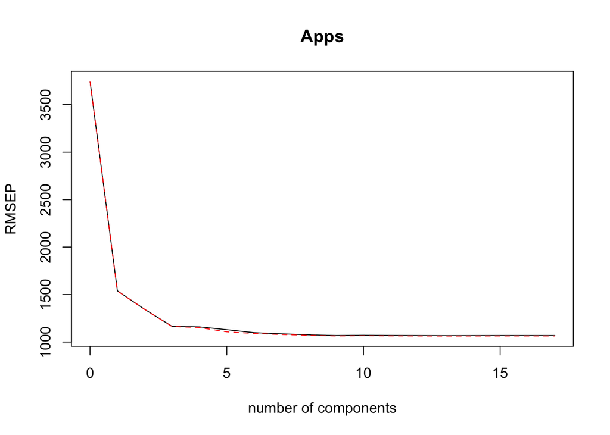

```r
set.seed(1)
pls.fit = plsr(Apps~., data = College, subset=train, scale=T, validation='CV')
validationplot(pls.fit)
```

```r
summary(pls.fit)
```

```
## Data:    X dimension: 400 17
##  Y dimension: 400 1
## Fit method: kernelpls
## Number of components considered: 17
##
## VALIDATION: RMSEP
## Cross-validated using 10 random segments.
##        (Intercept)  1 comps  2 comps  3 comps  4 comps  5 comps  6 comps
## CV            3744     1539     1344     1165     1160     1130     1098
## adjCV         3744     1538     1344     1163     1152     1107     1090
##        7 comps  8 comps  9 comps  10 comps  11 comps  12 comps  13 comps
## CV        1086     1076     1068      1071      1069      1068      1067
## adjCV     1079     1070     1064      1066      1064      1064      1063
##        14 comps  15 comps  16 comps  17 comps
## CV         1068      1069      1068      1068
## adjCV      1063      1064      1064      1064
##
## TRAINING: % variance explained
##       1 comps  2 comps  3 comps  4 comps  5 comps  6 comps  7 comps
## X       27.28    50.45    63.72    66.60    68.38    72.56    75.63
## Apps    83.57    87.63    90.98    91.71    92.72    92.99    93.06
##       8 comps  9 comps  10 comps  11 comps  12 comps  13 comps  14 comps
## X       79.99    83.33     85.84     88.70     91.51     93.71     96.30
## Apps    93.09    93.11     93.12     93.13     93.13     93.14     93.14
##       15 comps  16 comps  17 comps
## X        97.40     99.20    100.00
## Apps     93.14     93.14     93.14
```

MSE does not seem to change much after 8 components.

```r
pls.pred = predict(pls.fit, testx, ncomp=8)
pls.err = mean((pls.pred - College[test, 'Apps'])^2) / nrow(College[test,])
pls.err
```

```
## [1] 4092
```

## Question 10

Generate data and split into train/test.

```r
set.seed(1)
x = matrix(rnorm(1000*20), nrow=1000)
err = rnorm(1000)
coefs = rep(0, 20)
coefs[1] = 0.3
coefs[5] = 0.4
coefs[9] = 0.5
coefs[13] = 0.6
coefs[18] = 0.7
y = x%*%coefs + err
df = data.frame(x, y)
head(df)
```

```
##        X1      X2       X3      X4      X5      X6      X7      X8      X9
## 1 -0.6265  1.1350 -0.88615  0.7391 -1.1346 -1.5164 -0.6188 -1.3254  0.2637
## 2  0.1836  1.1119 -1.92225  0.3866  0.7646  0.6291 -1.1094  0.9520 -0.8295
## 3 -0.8356 -0.8708  1.61970  1.2964  0.5707 -1.6782 -2.1703  0.8600 -1.4616
## 4  1.5953  0.2107  0.51927 -0.8036 -1.3517  1.1798 -0.0313  1.0608  1.6840
## 5  0.3295  0.0694 -0.05585 -1.6026 -2.0299  1.1177 -0.2604 -0.3506 -1.5443
## 6 -0.8205 -1.6626  0.69642  0.9333  0.5905 -1.2377  0.5344 -0.1308 -0.1909
##        X10     X11     X12      X13     X14     X15     X16     X17
## 1 -1.21712 -0.8043 -1.4115 -0.93911  0.2265  0.5233 -0.2139  0.8576
## 2 -0.94623 -1.0565  1.0839  1.39366 -0.8186  0.9936 -0.1067 -1.6254
## 3  0.09141 -1.0354  1.1702  1.62581 -0.8472  0.2737 -0.4646 -0.2343
## 4  0.70135 -1.1856  0.2948  0.40900 -1.9843 -0.6949 -0.6843 -1.0327
## 5  0.67342 -0.5004 -0.5544 -0.09256 -0.8128 -0.7181 -0.7908 -1.1411
## 6  1.26555 -0.5250 -0.4034  0.20610  1.4617 -0.1020 -0.3390 -1.5219
##       X18     X19      X20       y
## 1  1.0496  0.9514 -2.07771 -0.1033
## 2  0.2903  0.4571 -0.45446  1.2304
## 3  1.2421 -0.3587 -0.16556  0.4496
## 4 -0.6851 -1.0459  0.89765 -1.3891
## 5 -0.6678  0.3075 -0.02949 -0.9695
## 6  0.9409  1.9944  1.85839  0.3934
```

```r
train = sample(1:1000, size = 100, replace = F)
test = -train
```

Run best subset selection.

```r
library(leaps)
reg.full = regsubsets(y~., df[train,], nvmax=20)
reg.summary = summary(reg.full)
reg.summary
```

```
## Subset selection object
## Call: regsubsets.formula(y ~ ., df[train, ], nvmax = 20)
## 20 Variables  (and intercept)
##     Forced in Forced out
## X1      FALSE      FALSE
## X2      FALSE      FALSE
## X3      FALSE      FALSE
## X4      FALSE      FALSE
## X5      FALSE      FALSE
## X6      FALSE      FALSE
## X7      FALSE      FALSE
## X8      FALSE      FALSE
## X9      FALSE      FALSE
## X10     FALSE      FALSE
## X11     FALSE      FALSE
## X12     FALSE      FALSE
## X13     FALSE      FALSE
## X14     FALSE      FALSE
## X15     FALSE      FALSE
## X16     FALSE      FALSE
## X17     FALSE      FALSE
## X18     FALSE      FALSE
## X19     FALSE      FALSE
## X20     FALSE      FALSE
## 1 subsets of each size up to 20
## Selection Algorithm: exhaustive
##           X1  X2  X3  X4  X5  X6  X7  X8  X9  X10 X11 X12 X13 X14 X15 X16
## 1  ( 1 )  " " " " " " " " " " " " " " " " " " " " " " " " " " " " " " " "
## 2  ( 1 )  " " " " " " " " " " " " " " " " " " " " " " " " "*" " " " " " "
## 3  ( 1 )  " " " " " " " " " " " " " " " " "*" " " " " " " "*" " " " " " "
## 4  ( 1 )  " " " " " " " " "*" " " " " " " "*" " " " " " " "*" " " " " " "
## 5  ( 1 )  "*" " " " " " " "*" " " " " " " "*" " " " " " " "*" " " " " " "
## 6  ( 1 )  "*" " " " " " " "*" " " " " " " "*" " " " " " " "*" "*" " " " "
## 7  ( 1 )  "*" " " " " " " "*" " " " " " " "*" " " " " " " "*" "*" " " " "
## 8  ( 1 )  "*" " " " " " " "*" " " " " " " "*" " " " " " " "*" "*" " " " "
## 9  ( 1 )  "*" " " " " " " "*" " " " " " " "*" " " " " " " "*" "*" "*" " "
## 10  ( 1 ) "*" " " " " " " "*" " " " " " " "*" " " " " " " "*" "*" "*" "*"
## 11  ( 1 ) "*" " " " " " " "*" "*" " " " " "*" " " " " " " "*" "*" "*" "*"
## 12  ( 1 ) "*" " " "*" " " "*" "*" " " " " "*" " " " " " " "*" "*" "*" "*"
## 13  ( 1 ) "*" " " "*" " " "*" "*" " " "*" "*" " " " " " " "*" "*" "*" "*"
```

[output cut: 13 more lines]

```
## 6  ( 1 )  " " "*" " " " "
## 7  ( 1 )  " " "*" " " "*"
## 8  ( 1 )  " " "*" "*" "*"
## 9  ( 1 )  " " "*" "*" "*"
## 10  ( 1 ) " " "*" "*" "*"
## 11  ( 1 ) " " "*" "*" "*"
## 12  ( 1 ) " " "*" "*" "*"
## 13  ( 1 ) " " "*" "*" "*"
## 14  ( 1 ) " " "*" "*" "*"
## 15  ( 1 ) " " "*" "*" "*"
## 16  ( 1 ) " " "*" "*" "*"
## 17  ( 1 ) "*" "*" "*" "*"
## 18  ( 1 ) "*" "*" "*" "*"
## 19  ( 1 ) "*" "*" "*" "*"
## 20  ( 1 ) "*" "*" "*" "*"
```

Seems to have worked pretty well. Let us look at the training error.

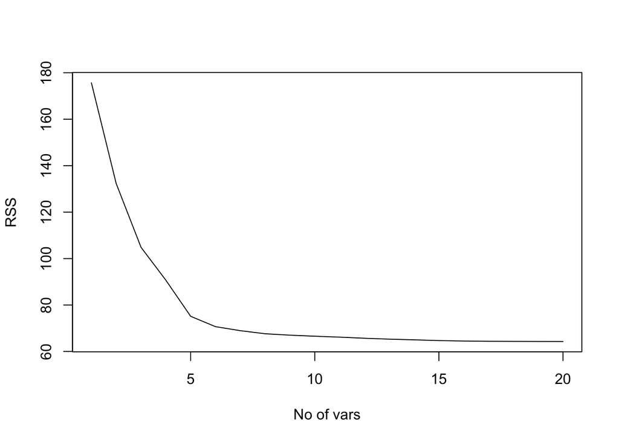

```r
plot(reg.summary$rss, xlab='No of vars', ylab='RSS', type='l')
```

```r
which.min(reg.summary$rss)
```

```
## [1] 20
```

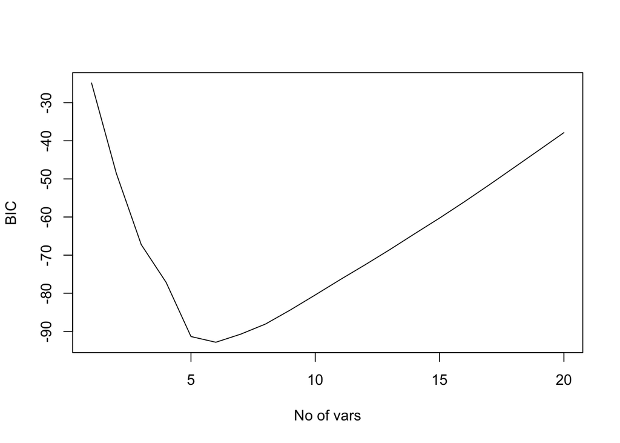

```r
plot(reg.summary$bic, xlab='No of vars', ylab='BIC', type='l')
```

```r
which.min(reg.summary$bic)
```

```
## [1] 6
```

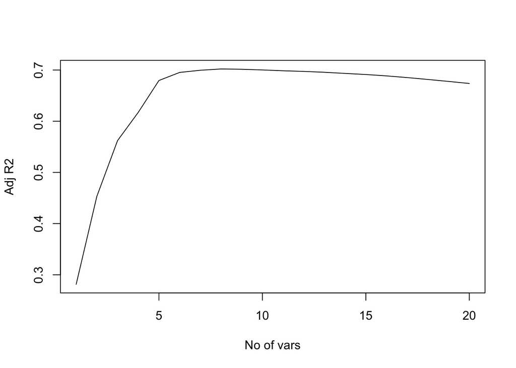

```r
plot(reg.summary$adjr2, xlab='No of vars', ylab='Adj R2', type='l')
```

```r
which.max(reg.summary$adjr2)
```

```
## [1] 8
```

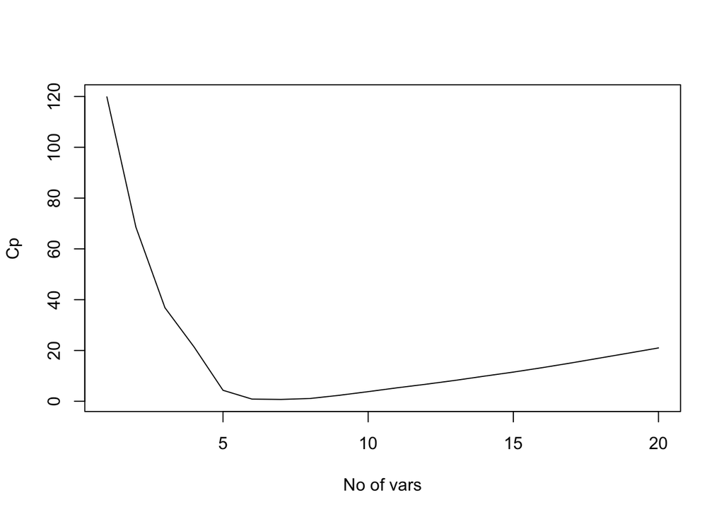

```r
plot(reg.summary$cp, xlab='No of vars', ylab='Cp', type='l')
```

```r
which.min(reg.summary$cp)
```

```
## [1] 7
```

```r
coef(reg.full, id=5)
```

```
## (Intercept)          X1          X5          X9         X13         X18
##     0.08643     0.39692     0.41236     0.62853     0.62617     0.76174
```

Let us calculate the test errors.

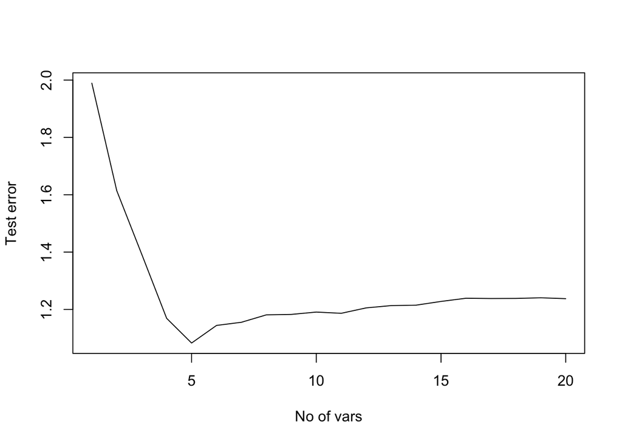

```r
predict.regsubsets = function(object, newdata, id){
  form = as.formula(object$call[[2]])
  mat = model.matrix(form, newdata)
  coefi = coef(object, id=id)
  xvars = names(coefi)
  mat[,xvars]%*%coefi
}
err.test = rep(NA, 20)
for( i in 1:20 )
{
  pred = predict.regsubsets(reg.full, newdata = df[test,], id = i)
  err.test[i] = mean((pred - df$y[test])^2)
}

plot(err.test, xlab='No of vars', ylab='Test error', type='l')
```

```r
which.min(err.test)
```

```
## [1] 5
```

```r
coef(reg.full, id=which.min(err.test))
```

```
## (Intercept)          X1          X5          X9         X13         X18
##     0.08643     0.39692     0.41236     0.62853     0.62617     0.76174
```

Test error reaches its minimum at the model with 5 predictors! Note that the coefficients are a bit larger than their actual values.

Let’s look at how the difference between the actual coefficients and their estimates change as the number of predictors change.

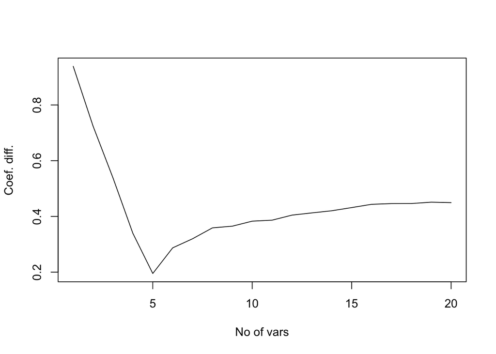

```r
colnames = c('(Intercept)', names(df)[1:20])
coef.actual = rep(0, 21)
names(coef.actual) = colnames
coef.actual['X1'] = 0.3
coef.actual['X5'] = 0.4
coef.actual['X9'] = 0.5
coef.actual['X13'] = 0.6
coef.actual['X18'] = 0.7

coef.est = rep(0, 21)
names(coef.est) = colnames
coef.diff = rep(NA, 20)
for(i in 1:20){
  mc = coef(reg.full, id=i)
  coef.est[names(mc)] = mc
  coef.diff[i] = sqrt(sum((coef.actual - coef.est)^2))
  coef.est[] = 0
}

plot(coef.diff, xlab='No of vars', ylab='Coef. diff.', type='l')
```

Looks good, the minimum is reached at 5 variables!

## Question 11

Load the `Boston` dataset and split it into training and test sets.

```r
library(MASS)
set.seed(1)
train = sample(c(T,F), size = nrow(Boston), replace = T)
test = !train
```

Fit a linear model.

```r
lm.fit = lm(crim~., data = Boston, subset = train)
summary(lm.fit)
```

```
##
## Call:
## lm(formula = crim ~ ., data = Boston, subset = train)
##
## Residuals:
##    Min     1Q Median     3Q    Max
##  -7.44  -1.75  -0.23   1.04  72.30
##
## Coefficients:
##             Estimate Std. Error t value Pr(>|t|)
## (Intercept) -3.26831    9.08050   -0.36  0.71920
## zn           0.04001    0.02203    1.82  0.07047 .
## indus        0.01314    0.10057    0.13  0.89615
## chas        -0.21329    1.31806   -0.16  0.87157
## nox         -5.01862    6.17541   -0.81  0.41715
## rm           2.74616    0.88573    3.10  0.00215 **
## age         -0.02398    0.02270   -1.06  0.29170
## dis         -0.89341    0.32038   -2.79  0.00569 **
## rad          0.51071    0.10612    4.81  2.5e-06 ***
## tax         -0.00363    0.00614   -0.59  0.55490
## ptratio     -0.26998    0.22695   -1.19  0.23530
## black        0.00764    0.00459    1.66  0.09732 .
## lstat        0.18953    0.09477    2.00  0.04657 *
## medv        -0.31483    0.08221   -3.83  0.00016 ***
## ---
## Signif. codes:  0 '***' 0.001 '**' 0.01 '*' 0.05 '.' 0.1 ' ' 1
##
## Residual standard error: 5.57 on 257 degrees of freedom
## Multiple R-squared:  0.492,  Adjusted R-squared:  0.466
## F-statistic: 19.1 on 13 and 257 DF,  p-value: <2e-16
```

Calculate MSE.

```r
lm.pred = predict(object = lm.fit, newdata = Boston[test,])
lm.err = mean((lm.pred - Boston[test, 'crim'])^2) / nrow(Boston[test,])
lm.err
```

```
## [1] 0.2526
```

Fit a ridge regression model.

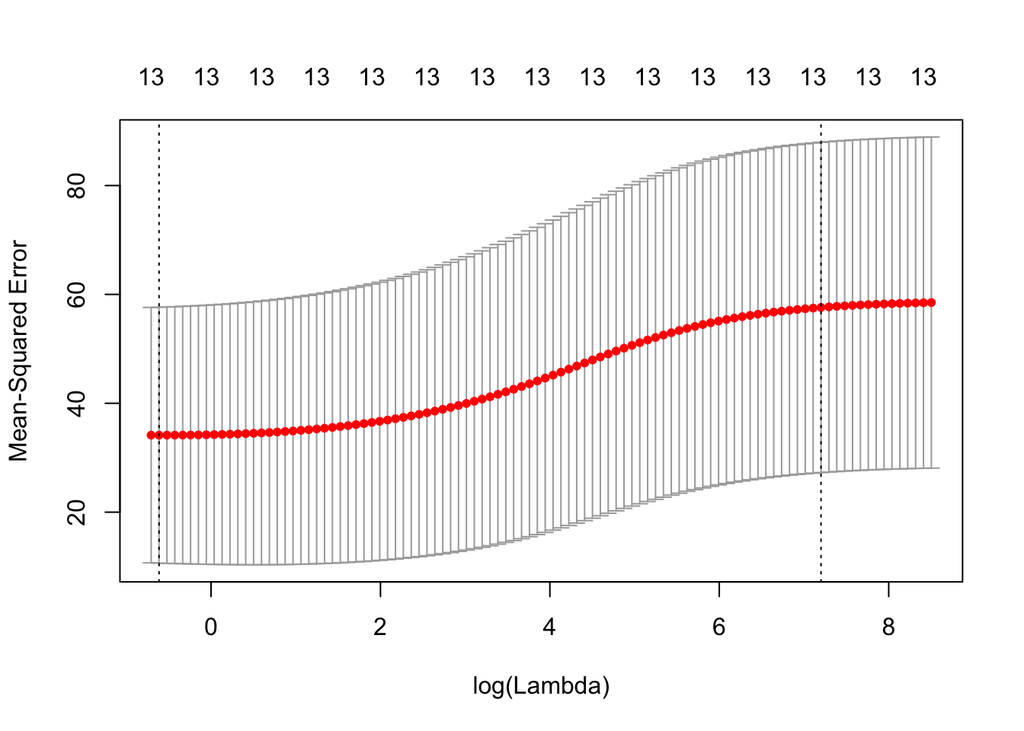

```r
library(glmnet)
set.seed(1)
mx = model.matrix(crim~., Boston)[,-1]
trainy = Boston[train, 'crim']
trainx = mx[train,]
testx = mx[test,]
ridge.fit = cv.glmnet(x = trainx, y = trainy, alpha = 0)
plot(ridge.fit)
```

```r
ridge.pred = predict(object = ridge.fit, newx = testx, s = 'lambda.min')
ridge.err = mean((ridge.pred - Boston[test, 'crim'])^2) / nrow(Boston[test,])
ridge.err
```

```
## [1] 0.2479
```

Fit a lasso regression model.

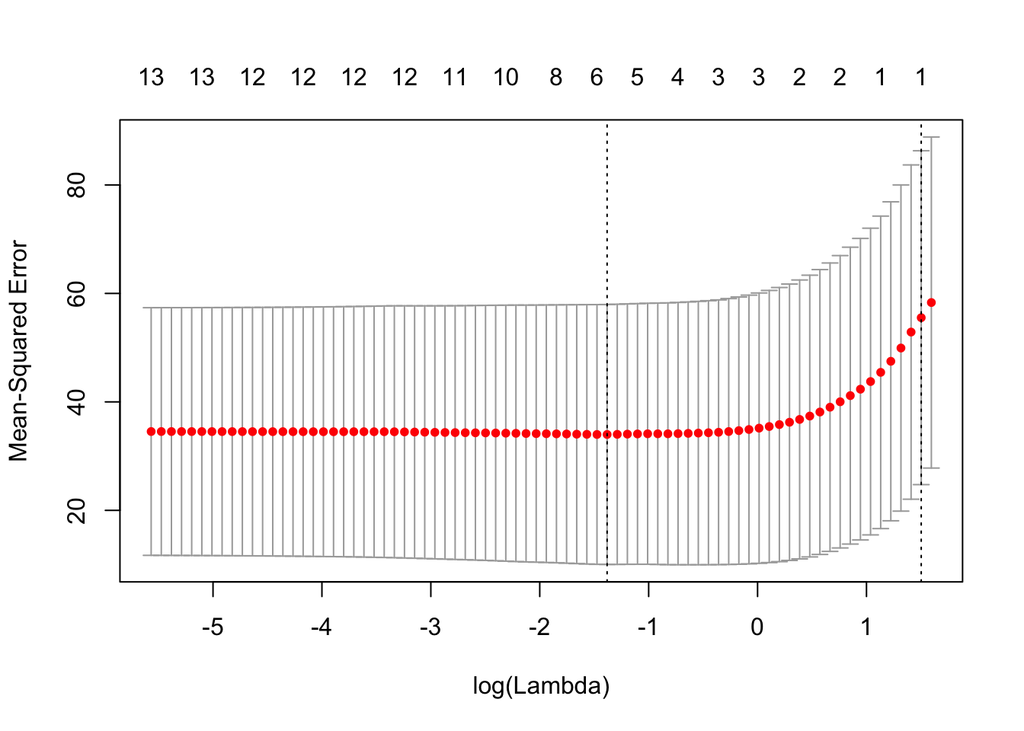

```r
set.seed(1)
lasso.fit = cv.glmnet(x = trainx, y = trainy, alpha = 1)
plot(lasso.fit)
```

```r
lasso.pred = predict(object = lasso.fit, newx = testx, s = 'lambda.min')
lasso.err = mean((lasso.pred - Boston[test, 'crim'])^2) / nrow(Boston[test,])
lasso.err
```

```
## [1] 0.2394
```

```r
coef(lasso.fit, s = 'lambda.min')
```

```
## 14 x 1 sparse Matrix of class "dgCMatrix"
##                     1
## (Intercept) -4.111126
## zn           0.008331
## indus        .
## chas         .
## nox          .
## rm           0.739227
## age          .
## dis         -0.178900
## rad          0.429970
## tax          .
## ptratio      .
## black        .
## lstat        0.129317
## medv        -0.105041
```

`rm` seems like an important predictor. Let us see what is going on in fact. Correlations between predictors should be informative.

```r
cor(Boston)
```

```
##             crim      zn    indus      chas     nox       rm      age
## crim     1.00000 -0.2005  0.40658 -0.055892  0.4210 -0.21925  0.35273
## zn      -0.20047  1.0000 -0.53383 -0.042697 -0.5166  0.31199 -0.56954
## indus    0.40658 -0.5338  1.00000  0.062938  0.7637 -0.39168  0.64478
## chas    -0.05589 -0.0427  0.06294  1.000000  0.0912  0.09125  0.08652
## nox      0.42097 -0.5166  0.76365  0.091203  1.0000 -0.30219  0.73147
## rm      -0.21925  0.3120 -0.39168  0.091251 -0.3022  1.00000 -0.24026
## age      0.35273 -0.5695  0.64478  0.086518  0.7315 -0.24026  1.00000
## dis     -0.37967  0.6644 -0.70803 -0.099176 -0.7692  0.20525 -0.74788
## rad      0.62551 -0.3119  0.59513 -0.007368  0.6114 -0.20985  0.45602
## tax      0.58276 -0.3146  0.72076 -0.035587  0.6680 -0.29205  0.50646
## ptratio  0.28995 -0.3917  0.38325 -0.121515  0.1889 -0.35550  0.26152
## black   -0.38506  0.1755 -0.35698  0.048788 -0.3801  0.12807 -0.27353
## lstat    0.45562 -0.4130  0.60380 -0.053929  0.5909 -0.61381  0.60234
## medv    -0.38830  0.3604 -0.48373  0.175260 -0.4273  0.69536 -0.37695
##              dis       rad      tax ptratio    black    lstat    medv
## crim    -0.37967  0.625505  0.58276  0.2899 -0.38506  0.45562 -0.3883
## zn       0.66441 -0.311948 -0.31456 -0.3917  0.17552 -0.41299  0.3604
## indus   -0.70803  0.595129  0.72076  0.3832 -0.35698  0.60380 -0.4837
## chas    -0.09918 -0.007368 -0.03559 -0.1215  0.04879 -0.05393  0.1753
## nox     -0.76923  0.611441  0.66802  0.1889 -0.38005  0.59088 -0.4273
## rm       0.20525 -0.209847 -0.29205 -0.3555  0.12807 -0.61381  0.6954
## age     -0.74788  0.456022  0.50646  0.2615 -0.27353  0.60234 -0.3770
## dis      1.00000 -0.494588 -0.53443 -0.2325  0.29151 -0.49700  0.2499
## rad     -0.49459  1.000000  0.91023  0.4647 -0.44441  0.48868 -0.3816
## tax     -0.53443  0.910228  1.00000  0.4609 -0.44181  0.54399 -0.4685
## ptratio -0.23247  0.464741  0.46085  1.0000 -0.17738  0.37404 -0.5078
## black    0.29151 -0.444413 -0.44181 -0.1774  1.00000 -0.36609  0.3335
## lstat   -0.49700  0.488676  0.54399  0.3740 -0.36609  1.00000 -0.7377
## medv     0.24993 -0.381626 -0.46854 -0.5078  0.33346 -0.73766  1.0000
```

As you see `rm` is highly correlated with both `lstat` and `medv`.

Fit PCR.

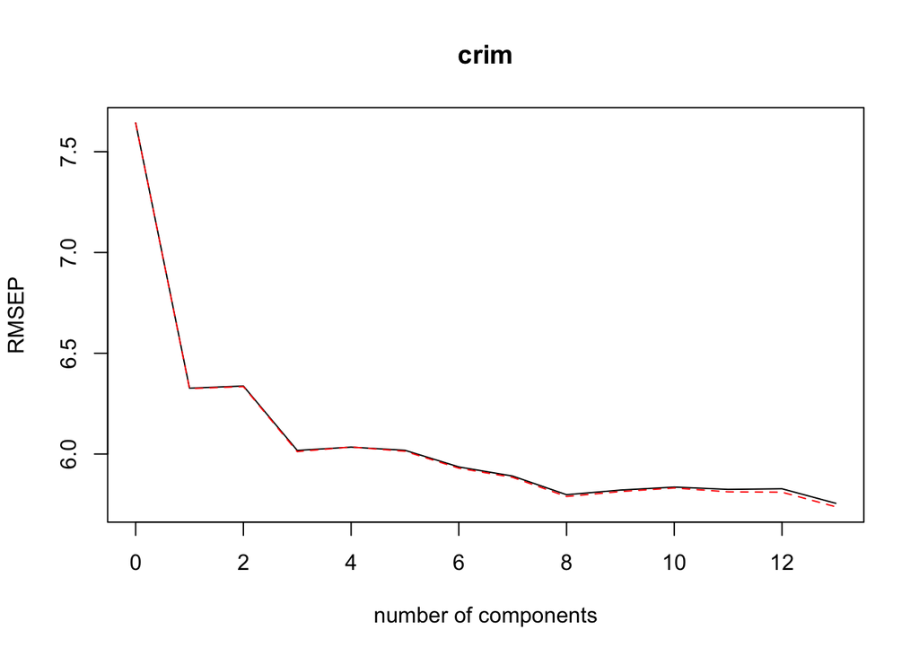

```r
set.seed(1)
library(pls)
pcr.fit = pcr(crim~., data = Boston, subset=train, scale=T, validation='CV')
validationplot(pcr.fit)
```

```r
summary(pcr.fit)
```

```
## Data:    X dimension: 271 13
##  Y dimension: 271 1
## Fit method: svdpc
## Number of components considered: 13
##
## VALIDATION: RMSEP
## Cross-validated using 10 random segments.
##        (Intercept)  1 comps  2 comps  3 comps  4 comps  5 comps  6 comps
## CV           7.643    6.327    6.338    6.018    6.034    6.019    5.936
## adjCV        7.643    6.324    6.335    6.012    6.035    6.014    5.930
##        7 comps  8 comps  9 comps  10 comps  11 comps  12 comps  13 comps
## CV       5.891    5.798    5.821     5.836     5.825     5.828     5.755
## adjCV    5.884    5.789    5.814     5.831     5.812     5.811     5.738
##
## TRAINING: % variance explained
##       1 comps  2 comps  3 comps  4 comps  5 comps  6 comps  7 comps
## X       48.90    62.42    71.23    77.96    84.40    89.39    92.32
## crim    31.95    32.00    39.49    39.49    40.09    41.80    42.79
##       8 comps  9 comps  10 comps  11 comps  12 comps  13 comps
## X        94.3    96.01     97.40     98.56     99.53    100.00
## crim     44.6    44.76     44.92     46.49     47.87     49.18
```

8 components seem like a good choice.

```r
pcr.pred = predict(pcr.fit, testx, ncomp=8)
pcr.err = mean((pcr.pred - Boston[test, 'crim'])^2) / nrow(Boston[test,])
pcr.err
```

```
## [1] 0.2408
```

PCR achieves a good MSE, but the problem is it is hard to interpret. Or is it? It doesn’t do feature selection, but it still tells you which predictors seem to be more important.

```r
coef(pcr.fit, ncomp=8)
```

```
## , , 8 comps
##
##             crim
## zn       0.28377
## indus   -1.05165
## chas    -0.20701
## nox      0.49093
## rm       0.32604
## age      0.37282
## dis     -0.08239
## rad      2.72108
## tax      1.88100
## ptratio -0.14355
## black    0.08688
## lstat    1.20945
## medv    -0.39198
```

Fit PLS.

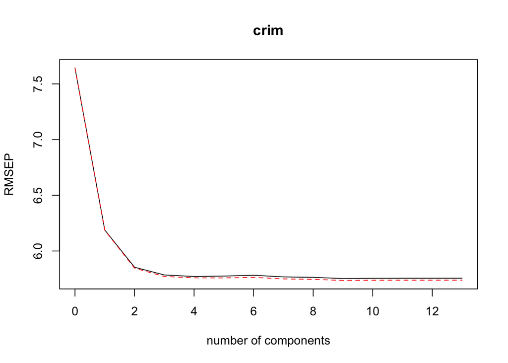

```r
set.seed(1)
pls.fit = plsr(crim~., data = Boston, subset=train, scale=T, validation='CV')
validationplot(pls.fit)
```

```r
summary(pls.fit)
```

```
## Data:    X dimension: 271 13
##  Y dimension: 271 1
## Fit method: kernelpls
## Number of components considered: 13
##
## VALIDATION: RMSEP
## Cross-validated using 10 random segments.
##        (Intercept)  1 comps  2 comps  3 comps  4 comps  5 comps  6 comps
## CV           7.643    6.189    5.854    5.785    5.771    5.775    5.782
## adjCV        7.643    6.186    5.846    5.771    5.759    5.758    5.763
##        7 comps  8 comps  9 comps  10 comps  11 comps  12 comps  13 comps
## CV       5.767    5.763    5.753     5.755     5.755     5.755     5.755
## adjCV    5.749    5.745    5.735     5.737     5.738     5.738     5.738
##
## TRAINING: % variance explained
##       1 comps  2 comps  3 comps  4 comps  5 comps  6 comps  7 comps
## X       48.54    57.10    61.79    71.16    77.75    81.24    85.49
## crim    35.41    44.24    47.16    48.04    48.64    48.96    49.07
##       8 comps  9 comps  10 comps  11 comps  12 comps  13 comps
## X       87.69    89.37     95.61     97.08     98.56    100.00
## crim    49.15    49.18     49.18     49.18     49.18     49.18
```

MSE does not seem to change much after 4 components.

```r
pls.pred = predict(pls.fit, testx, ncomp=4)
pls.err = mean((pls.pred - Boston[test, 'crim'])^2) / nrow(Boston[test,])
pls.err
```

```
## [1] 0.2521
```

```r
coef(pcr.fit, ncomp=4)
```

```
## , , 4 comps
##
##            crim
## zn       0.2376
## indus    0.5639
## chas    -0.6654
## nox      0.4691
## rm       0.4211
## age      0.1690
## dis     -0.1993
## rad      1.4230
## tax      1.3386
## ptratio  0.6659
## black   -1.0192
## lstat    0.3172
## medv    -0.2644
```

Run best subset selection.

```r
library(leaps)
reg.full = regsubsets(crim~., Boston[train,], nvmax=13)
reg.summary = summary(reg.full)
reg.summary
```

```
## Subset selection object
## Call: regsubsets.formula(crim ~ ., Boston[train, ], nvmax = 13)
## 13 Variables  (and intercept)
##         Forced in Forced out
## zn          FALSE      FALSE
## indus       FALSE      FALSE
## chas        FALSE      FALSE
## nox         FALSE      FALSE
## rm          FALSE      FALSE
## age         FALSE      FALSE
## dis         FALSE      FALSE
## rad         FALSE      FALSE
## tax         FALSE      FALSE
## ptratio     FALSE      FALSE
## black       FALSE      FALSE
## lstat       FALSE      FALSE
## medv        FALSE      FALSE
## 1 subsets of each size up to 13
## Selection Algorithm: exhaustive
##           zn  indus chas nox rm  age dis rad tax ptratio black lstat medv
## 1  ( 1 )  " " " "   " "  " " " " " " " " "*" " " " "     " "   " "   " "
## 2  ( 1 )  " " " "   " "  " " " " " " " " "*" " " " "     " "   "*"   " "
## 3  ( 1 )  " " " "   " "  " " "*" " " " " "*" " " " "     " "   " "   "*"
## 4  ( 1 )  " " " "   " "  " " "*" " " " " "*" " " " "     " "   "*"   "*"
## 5  ( 1 )  "*" " "   " "  " " "*" " " "*" "*" " " " "     " "   " "   "*"
## 6  ( 1 )  "*" " "   " "  " " "*" " " "*" "*" " " " "     " "   "*"   "*"
## 7  ( 1 )  "*" " "   " "  " " "*" " " "*" "*" " " " "     "*"   "*"   "*"
## 8  ( 1 )  "*" " "   " "  " " "*" "*" "*" "*" " " " "     "*"   "*"   "*"
## 9  ( 1 )  "*" " "   " "  " " "*" "*" "*" "*" " " "*"     "*"   "*"   "*"
## 10  ( 1 ) "*" " "   " "  "*" "*" "*" "*" "*" " " "*"     "*"   "*"   "*"
## 11  ( 1 ) "*" " "   " "  "*" "*" "*" "*" "*" "*" "*"     "*"   "*"   "*"
## 12  ( 1 ) "*" " "   "*"  "*" "*" "*" "*" "*" "*" "*"     "*"   "*"   "*"
## 13  ( 1 ) "*" "*"   "*"  "*" "*" "*" "*" "*" "*" "*"     "*"   "*"   "*"
```

Seems to have worked pretty well. Let us look at the training error.

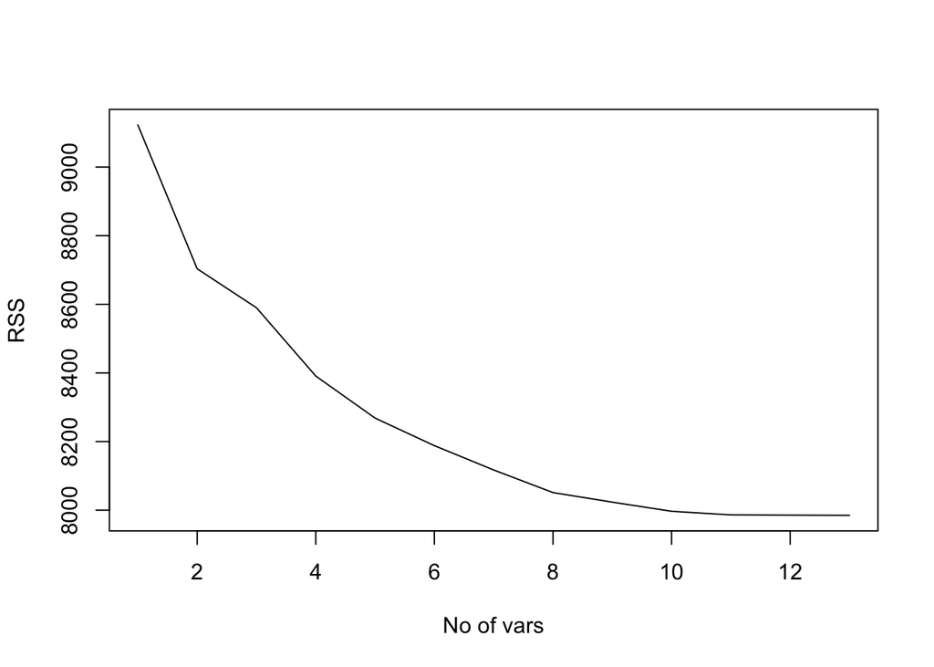

```r
plot(reg.summary$rss, xlab='No of vars', ylab='RSS', type='l')
```

```r
which.min(reg.summary$rss)
```

```
## [1] 13
```

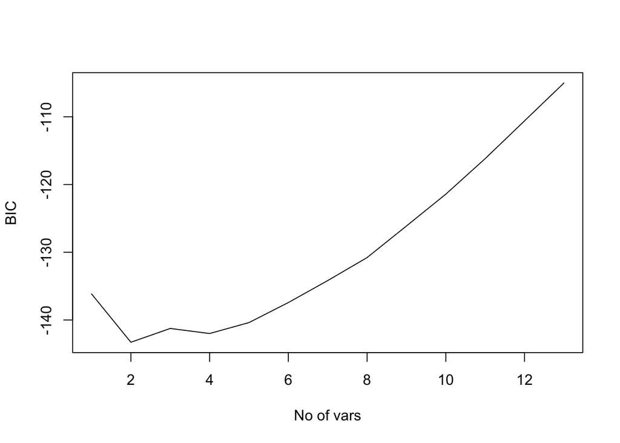

```r
plot(reg.summary$bic, xlab='No of vars', ylab='BIC', type='l')
```

```r
which.min(reg.summary$bic)
```

```
## [1] 2
```